# Case_Study_Script

2025-04-29

Assignment Partition the data into training (60%) and validation (40%). Use seed = 1.

```r
# Load libraries
library(dplyr)
```

```r
library(class)
library(ggplot2)
library(caret)
getwd()
```

```
## [1] "/Users/lisaluiten/Desktop/Grad School"
```

```r
# Load dataset
cbc <- read.csv("CharlesBookClub.csv")

# Partition dataset
set.seed(1)
split <- createDataPartition(cbc$Florence, p = 0.6, list = FALSE)
train <- cbc[split, ]
valid <- cbc[-split, ]

#Training set: 2,400 customers
#Validation set: 1,600 customers
```

1. What is the response rate for the training data customers taken as a whole? What is the response rate for each of the 4 × 5 × 3 = 60 combinations of RFM categories? Which combinations have response rates in the training data that are above the overall response in the training data?

```r
# Overall response rate
overall_response_rate <- mean(train$Florence)
#   Overall Response Rate (Training Set): 8.71%

# Calculate RFM response rates
rfm_rates <- train %>%
  group_by(Rcode, Mcode, Fcode) %>%
  summarise(response_rate = mean(Florence), num_customers = n(), .groups = 'drop') %>%
  mutate(above_average = response_rate > overall_response_rate)


# Filter above-average RFM combinations
above_avg <- rfm_rates %>% filter(above_average)
print(above_avg) #Combinations that have above average response rates.
```

```
## # A tibble: 19 × 6
##    Rcode Mcode Fcode response_rate num_customers above_average
##    <int> <int> <int>         <dbl>         <int> <lgl>
##  1     1     2     2         0.5               2 TRUE
##  2     1     2     3         1                 1 TRUE
##  3     1     4     1         0.25             16 TRUE
##  4     1     5     1         0.115            26 TRUE
##  5     1     5     2         0.118            17 TRUE
##  6     1     5     3         0.170            53 TRUE
##  7     2     1     1         0.333             3 TRUE
##  8     2     2     1         0.333             9 TRUE
##  9     2     3     1         0.136            22 TRUE
## 10     2     3     2         0.167            24 TRUE
## 11     2     3     3         0.333             6 TRUE
## 12     2     4     2         0.114            35 TRUE
## 13     2     4     3         0.146            41 TRUE
## 14     2     5     1         0.179            28 TRUE
## 15     2     5     2         0.114            44 TRUE
## 16     2     5     3         0.151            93 TRUE
## 17     3     3     2         0.1              40 TRUE
## 18     3     5     3         0.153           215 TRUE
## 19     4     3     3         0.118            17 TRUE
```

2. Suppose that we decide to send promotional mail only to the “above-average” RFM combinations identified in part 1. Compute the response rate in the validation data using these combinations.

```r
valid_above_avg <- valid %>%
  inner_join(above_avg, by = c("Rcode", "Mcode", "Fcode"))

validation_response_rate <- mean(valid_above_avg$Florence)

nrow(valid_above_avg) #446 customers targeted in validation set
```

```
## [1] 446
```

```r
sum(valid_above_avg$Florence) #46 buyers identified in targeted validation set
```

```
## [1] 46
```

```r
print(validation_response_rate) #10.314% response rate in validation set
```

```
## [1] 0.103139
```

```r
#We see a slight increase in buying, when original overall response rate was 8.71% and targeted resposne rate becomes 10.31%.
```

3. Rework parts 1 and 2 with three segments:

Segment 1: RFM combinations that have response rates that exceed twice the overall response rate Segment 2: RFM combinations that exceed the overall response rate but do not exceed twice that rate Segment 3: the remaining RFM combinations Draw the lift curve (consisting of three points for these three segments) showing the number of customers in the validation dataset on the x-axis and cumulative number of buyers in the validation dataset on the y-axis.

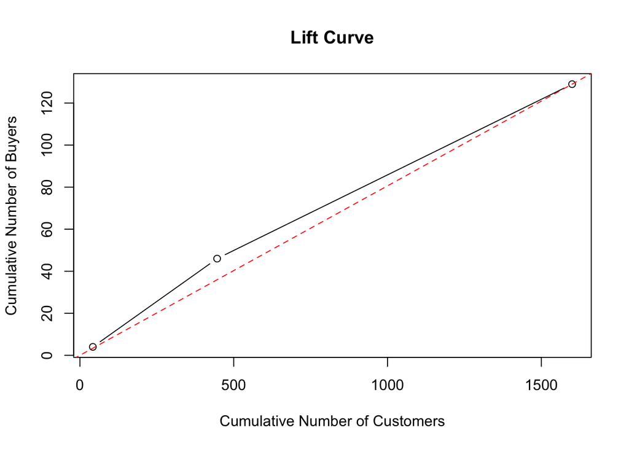

```r
# Segment assignment
twice_overall <- 2 * overall_response_rate


#Segmenting sections
rfm_rates2 <- rfm_rates %>%
  mutate(segment = case_when(
    response_rate > twice_overall ~ "Segment 1",
    response_rate > overall_response_rate ~ "Segment 2",
    TRUE ~ "Segment 3"
  ))


# Merge segment info
valid_segments <- valid %>%
  left_join(rfm_rates2[, c("Rcode", "Mcode", "Fcode", "segment")], by = c("Rcode", "Mcode", "Fcode"))

# Segment lift data
segment_summary <- valid_segments %>%
  group_by(segment) %>%
  summarise(customers = n(), buyers = sum(Florence), .groups = 'drop')


# Lift Chart
segment_summary$segment <- factor(segment_summary$segment,
                                  levels = c("Segment 1", "Segment 2", "Segment 3"))

segment_summary <- segment_summary %>%
  arrange(segment) %>%
  mutate(cum_customers = cumsum(customers),
         cum_buyers = cumsum(buyers))

plot(segment_summary$cum_customers, segment_summary$cum_buyers,
     type = "b",
     xlab = "Cumulative Number of Customers",
     ylab = "Cumulative Number of Buyers",
     main = "Lift Curve")
abline(a = 0,
       b = max(segment_summary$cum_buyers) / max(segment_summary$cum_customers),
       lty = 2,  # dashed line
       col = "red")
```

```r
#Segment 2 are more likely to respond (recent buyers are more valuable than big/medium spenders).
```

-Nearest Neighbors The k-nearest-neighbors technique can be used to create segments based on product proximity to similar products of the products offered as well as the propensity to purchase (as measured by the RFM variables). For The Art History of Florence, a possible segmentation by product proximity could be created using the following variables:

R: recency—months since last purchase F: frequency—total number of past purchases M: monetary—total money (in dollars) spent on books FirstPurch: months since first purchase RelatedPurch: total number of past purchases of related books (i.e., sum of purchases from the art and geography categories and of titles Secrets of Italian Cooking, Historical Atlas of Italy, and Italian Art)

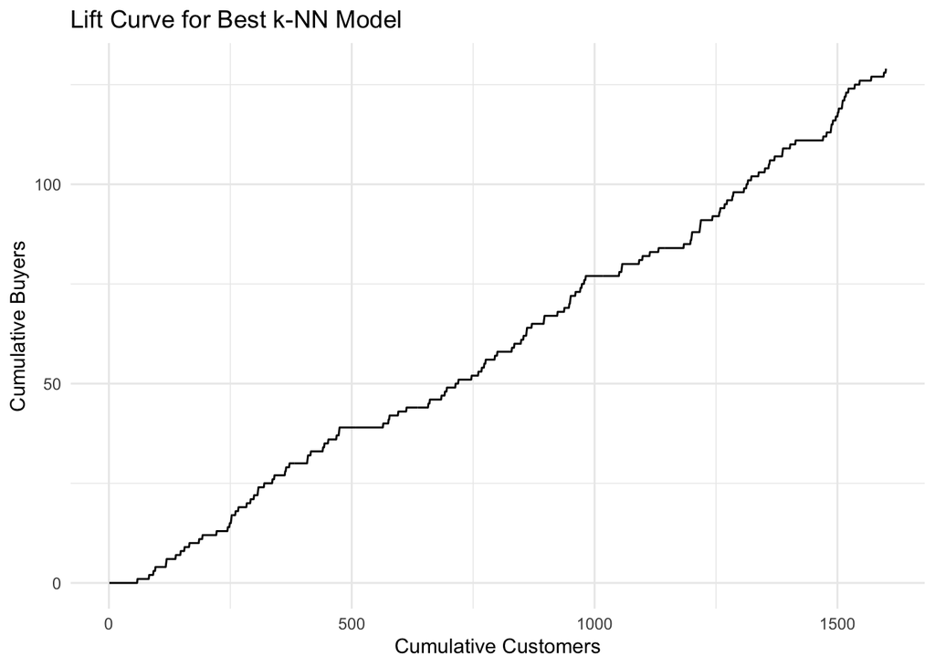

```r
# Normalize features for k-NN
features <- scale(train[, c("R", "F", "M", "FirstPurch", "Related.Purchase")])
features_valid <- scale(valid[, c("R", "F", "M", "FirstPurch", "Related.Purchase")], center = attr(features, "scaled:center"), scale = attr(features, "scaled:scale"))

# Find best k
best_acc <- 0
best_k <- 1
for (k in 1:11) {
  pred <- knn(train = features, test = features_valid, cl = train$Florence, k = k)
  acc <- mean(pred == valid$Florence)
  if (acc > best_acc) {
    best_acc <- acc
    best_k <- k
  }
}

# k=8 is the best model
# Validation Accuracy: 91.9%


# Final k-NN model
pred_prob <- attr(knn(train = features, test = features_valid, cl = train$Florence, k = best_k, prob = TRUE), "prob")


# Lift curve plot
lift_df <- data.frame(prob = pred_prob, actual = valid$Florence)
lift_df <- lift_df %>% arrange(desc(prob))
lift_df$cumulative_buyers <- cumsum(lift_df$actual)
lift_df$customer_number <- 1:nrow(lift_df)

ggplot(lift_df, aes(x = customer_number, y = cumulative_buyers)) +
  geom_line() +
  labs(title = "Lift Curve for Best k-NN Model", x = "Cumulative Customers", y = "Cumulative Buyers") +
  theme_minimal()
```

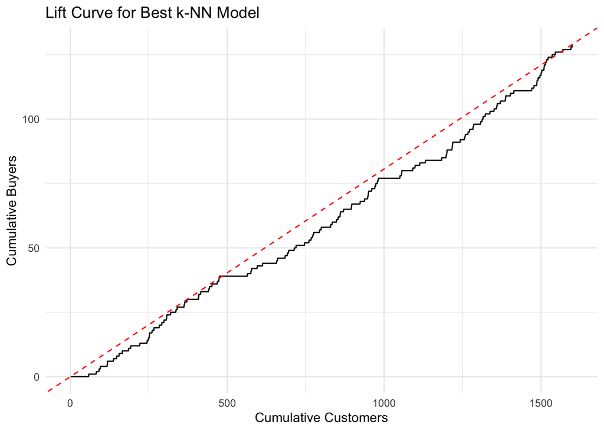

```r
ggplot(lift_df, aes(x = customer_number, y = cumulative_buyers)) +
  geom_line() +
  geom_abline(
    slope = max(lift_df$cumulative_buyers) / max(lift_df$customer_number),
    intercept = 0,
    linetype = "dashed",
    color = "red"
  ) +
  labs(
    title = "Lift Curve for Best k-NN Model",
    x = "Cumulative Customers",
    y = "Cumulative Buyers"
  ) +
  theme_minimal()
```

```r
#Predictive model is not much different from that of a randomized method. This is not very good.
```

5. The k-NN prediction algorithm gives a numerical value, which is a weighted average of the values of the Florence variable for the k-nearest neighbors with weights that are inversely proportional to distance. Using the best k that you calculated above with k-NN classification, now run a model with k-NN prediction and compute a lift curve for the validation data. Use all 5 predictors and normalized data. What is the range within which a prediction will fall? How does this result compare to the output you get with the k-nearest-neighbor classification?

```r
library(FNN)
```

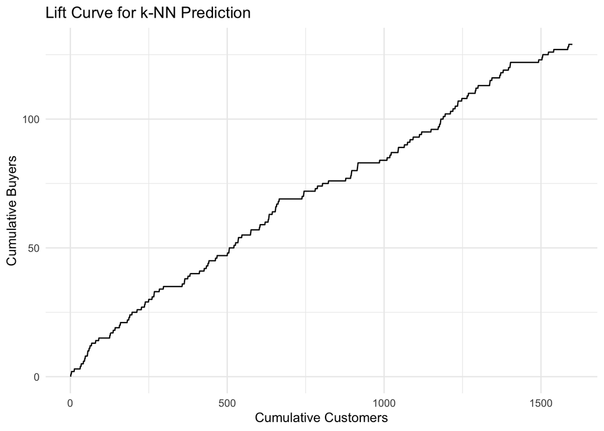

```r
# Run k-NN prediction
knn_pred <- knn.reg(train = features, test = features_valid,
                    y = train$Florence, k = best_k)

pred_values <- knn_pred$pred

# Create lift curve
lift_df_reg <- data.frame(pred = pred_values, actual = valid$Florence)
lift_df_reg <- lift_df_reg %>% arrange(desc(pred))
lift_df_reg$cumulative_buyers <- cumsum(lift_df_reg$actual)
lift_df_reg$customer_number <- 1:nrow(lift_df_reg)

# Plot
ggplot(lift_df_reg, aes(x = customer_number, y = cumulative_buyers)) +
  geom_line() +
  labs(title = "Lift Curve for k-NN Prediction",
       x = "Cumulative Customers",
       y = "Cumulative Buyers") +
  theme_minimal()
```

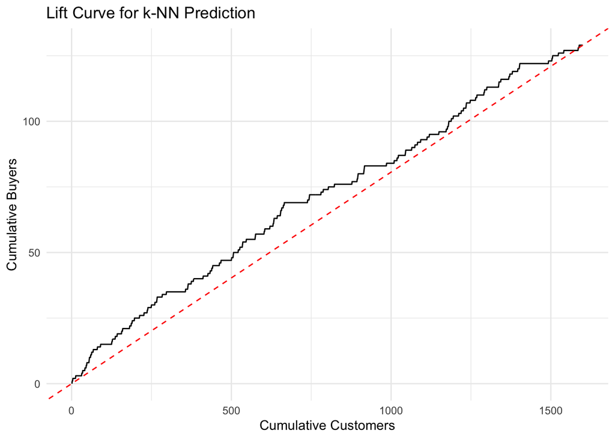

```r
ggplot(lift_df_reg, aes(x = customer_number, y = cumulative_buyers)) +
  geom_line() +
  geom_abline(
    slope = max(lift_df_reg$cumulative_buyers) / max(lift_df_reg$customer_number),
    intercept = 0,
    linetype = "dashed",
    color = "red"
  ) +
  labs(
    title = "Lift Curve for k-NN Prediction",
    x = "Cumulative Customers",
    y = "Cumulative Buyers"
  ) +
  theme_minimal()
```

```r
#Incorporating all factors, we get a better predictive model.
#Using 8 most similar purchases made by other consumers, we get a better predictive model to understand if a customer will purchase Florence.
```

Logistic Regression The logistic regression model offers a powerful method for modeling response because it yields well-defined purchase probabilities. The model is especially attractive in consumer-choice settings because it can be derived from the random utility theory of consumer behavior.

The full set of 15 predictors in the dataset A subset of predictors that you judge to be the best Only the R, F, and M variables

```r
#Full set of 15 predictors
model_full <- glm(
  Florence ~ Gender + M + R + F + FirstPurch +
    ChildBks + YouthBks + CookBks + DoItYBks + RefBks +
    ArtBks + GeogBks + ItalCook + ItalAtlas + ItalArt,
  data = train,
  family = "binomial"
)
summary(model_full)
```

```
##
## Call:
## glm(formula = Florence ~ Gender + M + R + F + FirstPurch + ChildBks +
##     YouthBks + CookBks + DoItYBks + RefBks + ArtBks + GeogBks +
##     ItalCook + ItalAtlas + ItalArt, family = "binomial", data = train)
##
## Coefficients:
##               Estimate Std. Error z value Pr(>|z|)
## (Intercept) -2.3143644  0.2584677  -8.954  < 2e-16 ***
## Gender      -0.3389381  0.1563721  -2.168 0.030196 *
## M            0.0001257  0.0008788   0.143 0.886245
## R           -0.0299126  0.0155749  -1.921 0.054787 .
## F            0.2048026  0.0649261   3.154 0.001608 **
## FirstPurch  -0.0005054  0.0110170  -0.046 0.963407
## ChildBks    -0.1773853  0.1057749  -1.677 0.093541 .
## YouthBks    -0.2621029  0.1517956  -1.727 0.084225 .
## CookBks     -0.3732984  0.1098566  -3.398 0.000679 ***
## DoItYBks    -0.1841962  0.1329718  -1.385 0.165983
## RefBks      -0.2272505  0.1542431  -1.473 0.140663
## ArtBks       0.4823741  0.1012087   4.766 1.88e-06 ***
## GeogBks      0.2408928  0.0976610   2.467 0.013639 *
## ItalCook    -0.0614844  0.1981087  -0.310 0.756290
## ItalAtlas   -0.8621905  0.5085769  -1.695 0.090018 .
## ItalArt      0.2700183  0.2793200   0.967 0.333695
## ---
## Signif. codes:  0 '***' 0.001 '**' 0.01 '*' 0.05 '.' 0.1 ' ' 1
##
## (Dispersion parameter for binomial family taken to be 1)
##
##     Null deviance: 1419.5  on 2399  degrees of freedom
## Residual deviance: 1326.3  on 2384  degrees of freedom
## AIC: 1358.3
##
## Number of Fisher Scoring iterations: 5
```

```r
#Subset of predictors
#Using gender, F, Cookbks, Artbks, and geogbks. significant p-value
model_best <- glm(
  Florence ~ Gender + F + CookBks +  ArtBks + GeogBks,
  data = train,
  family = "binomial"
)
summary(model_best)
```

```
##
## Call:
## glm(formula = Florence ~ Gender + F + CookBks + ArtBks + GeogBks,
##     family = "binomial", data = train)
##
## Coefficients:
##             Estimate Std. Error z value Pr(>|z|)
## (Intercept) -2.62014    0.15525 -16.876  < 2e-16 ***
## Gender      -0.30455    0.15447  -1.972 0.048662 *
## F            0.10555    0.02812   3.753 0.000175 ***
## CookBks     -0.37022    0.09985  -3.708 0.000209 ***
## ArtBks       0.47491    0.09740   4.876 1.08e-06 ***
## GeogBks      0.22810    0.09286   2.456 0.014032 *
## ---
## Signif. codes:  0 '***' 0.001 '**' 0.01 '*' 0.05 '.' 0.1 ' ' 1
##
## (Dispersion parameter for binomial family taken to be 1)
##
##     Null deviance: 1419.5  on 2399  degrees of freedom
## Residual deviance: 1354.7  on 2394  degrees of freedom
## AIC: 1366.7
##
## Number of Fisher Scoring iterations: 5
```

```r
#RFM only
model_rfm <- glm(Florence ~ R + F + M, data = train, family = "binomial")
summary(model_rfm)
```

```
##
## Call:
## glm(formula = Florence ~ R + F + M, family = "binomial", data = train)
##
## Coefficients:
##               Estimate Std. Error z value Pr(>|z|)
## (Intercept) -2.1849245  0.2087354 -10.467  < 2e-16 ***
## R           -0.0430210  0.0104229  -4.128 3.67e-05 ***
## F            0.0682130  0.0225798   3.021  0.00252 **
## M            0.0003560  0.0008456   0.421  0.67375
## ---
## Signif. codes:  0 '***' 0.001 '**' 0.01 '*' 0.05 '.' 0.1 ' ' 1
##
## (Dispersion parameter for binomial family taken to be 1)
##
##     Null deviance: 1419.5  on 2399  degrees of freedom
## Residual deviance: 1386.4  on 2396  degrees of freedom
## AIC: 1394.4
##
## Number of Fisher Scoring iterations: 5
```

```r
# Frequency is consistently a significant value, across all three of these logistic regressions.
# Frequency refers to the number of times a customer has made a purchase within a specific time frame.
# Frequency and Artbks are highly significant and positive variables in determining if Florence is purchased.
```

6. Create a lift chart summarizing the results from the three logistic regression models created above, along with the expected lift for a random selection of an equal number of customers from the validation dataset.

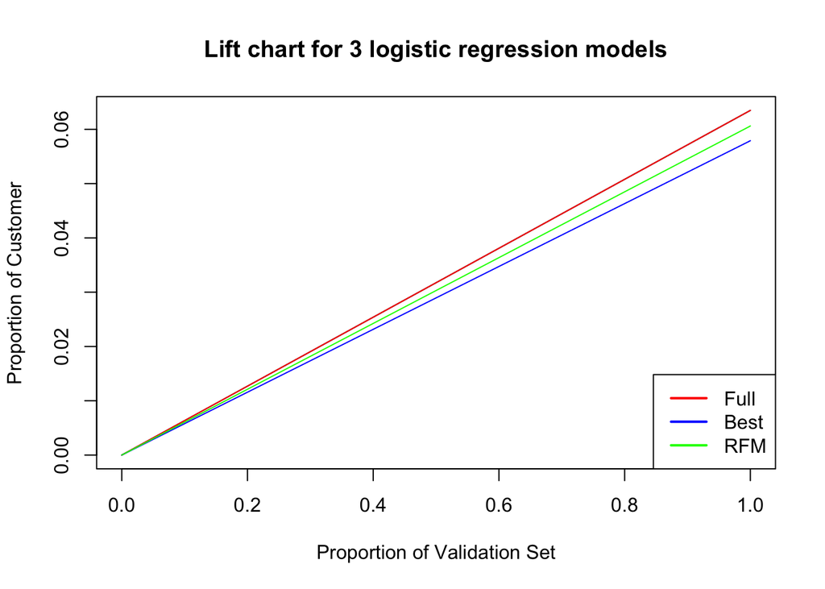

```r
pred_full <- predict(model_full, newdata = valid, type="response")
pred_best <- predict(model_best, newdata = valid, type="response")
pred_rfm <- predict(model_rfm, newdata = valid, type="response")

library(gains)

actual <- valid$Florence

gain_full <- gains(actual, pred_full, groups = 10)
gain_best <- gains(actual, pred_best, groups = 10)
gain_rfm  <- gains(actual, pred_rfm, groups = 10)

#Plot the lift chart
plot(c(0, sum(gain_full$depth) / sum(gain_full$depth)),
     c(0, sum(gain_full$cume.pct.of.total) / 100),
     xlab = "Proportion of Validation Set", ylab = "Proportion of Customer", main = "Lift chart for 3 logistic regression models", type="l")

lines(c(0, sum(gain_full$depth) / sum(gain_full$depth)),
      c(0, sum(gain_full$cume.pct.of.total) / 100),
      col = "red", lwd=1)

lines(c(0, sum(gain_best$depth) / sum(gain_best$depth)),
      c(0, sum(gain_best$cume.pct.of.total) / 100),
      col = "blue", lwd=1)

lines(c(0, sum(gain_rfm$depth) / sum(gain_rfm$depth)),
      c(0, sum(gain_rfm$cume.pct.of.total) / 100),
      col = "green", lwd=1)

legend("bottomright", legend = c("Full", "Best", "RFM"),
       col = c("red", "blue", "green"), lty = c(1,1,1), lwd = 2)
```

```r
# Of the three logistic regressions, full represents the most accurate model. (Uses all variables)
```

7. If the cutoff criterion for a campaign is a 30% likelihood of a purchase, find the customers in the validation data that would be targeted and count the number of buyers in this set.

```r
targeted <- valid[pred_best >= 0.3,]

num_targeted <- nrow(targeted)
num_responders <- sum(targeted$Florence)

#Customers targeted: 12
#Actual buyers: 4
```

8. Using the Neural Net

```r
library(neuralnet)
library(caret)

#normalize the train dataset
train.norm <- train
book.norm <- preProcess(train.norm[,4:6], method="range")
train.norm[,4:6] <- predict(book.norm, train.norm[,4:6])

#Apply neural net based on the inputs of M + R + F
book.nn <- neuralnet(Yes_Florence + No_Florence ~ M + R + F, data = train.norm, linear.output = F, hidden = 2)
invisible(prediction(book.nn))
```

```
## Data Error:  8.33333333333333;
```

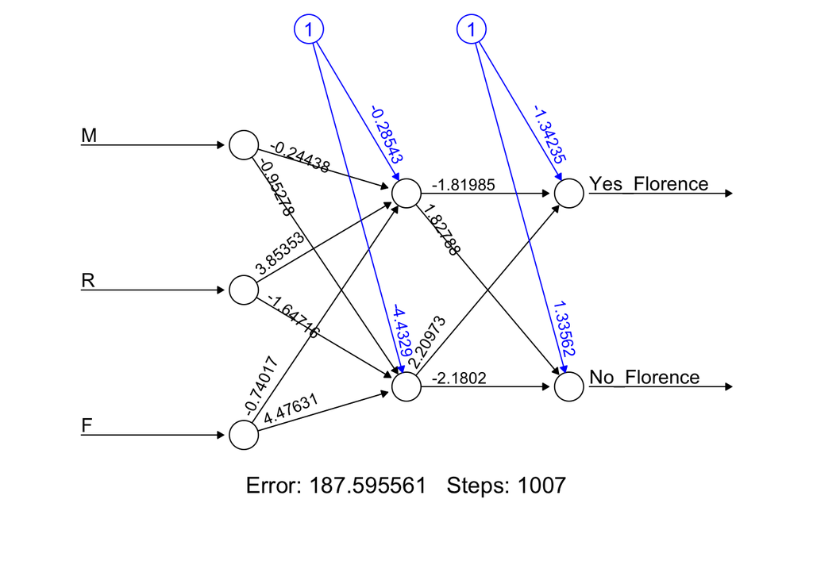

```r
plot(book.nn, rep="best")
```

```r
# Frequency has the strongest correlation to being a yes purchase on Florence.
```